# Pricing the Pandemic

How COVID-19 Events Moved Markets

Tuan Tran & Marsya Amanda  
Mentored by Dr. Beilei Bian

# Motivation & Background

**Motivation**

- Investigate market perception of pharmaceutical innovation and public health news.
- Learn and apply event studies methods to study investor behaviour under uncertainty.

**Background**

- The widespread impact of COVID-19 events and vaccine innovation have been investigated in previous studies, but with less focus of the impact of these events on vaccine-producing companies themselves.
- We focus on the three largest COVID-19 vaccine-producing companies by market capitalisation: Oxford-AstraZeneca, Janssen-Cilag International NV (sub-company of Johnson & Johnson), and Pfizer-BioNTech.
- Pfizer-BioNTech was the first COVID-19 vaccine to be approved by the United States Food and Drugs Association.

# Methods

## Data Collection

- **Tools:** `yfR` (Yahoo Finance) R package.
- **Time period:** January 30, 2015 to November 8, 2025
- **Stocks:** Pfizer-BioNTech `(PFE)`, Oxford-AstraZeneca `(AZN)`, Johnson & Johnson `(JNJ)`
- **Foreign exchange rates:** GBP to USD exchange rate `(GBPUSD)`
- **Market & risk-free rates:** S&P 500 `(GSPC)`, 10-year US treasury yields `(TNX)`

# Exploratory Data Analysis (EDA)

## Data Description

- We used time-series analysis on cumulative returns at time $i$ on each stock which was calculated from the **`price_adjusted`** column values.

  $$\text{cumulative return}_i = \frac{\text{adjusted price}_i - \text{adjusted price}_0}{\text{adjusted price}_i}$$
- **Events** were divided into two categories:
  - **Market-wide**: events which were announced by international or governmental health organisations.
  - **Firm-specific**: events which were announced or initiated by firms themselves.

## Market-wide events

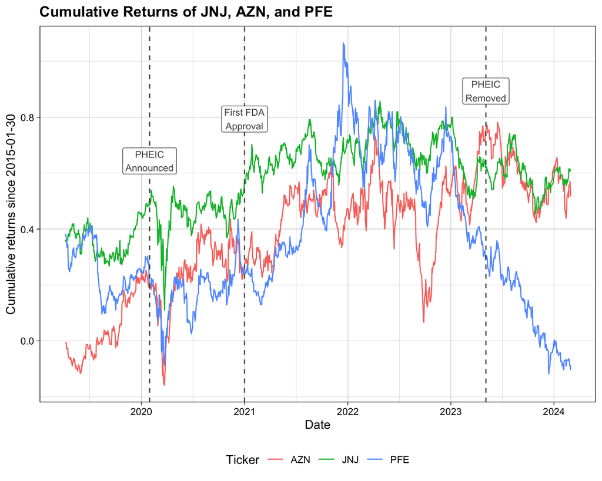

### Observations

- Large dip in the months following official WHO pandemic announcement (PHEIC).
- Effect of the first-ever FDA-approved COVID-19 vaccine is unclear.
- Dip in all three stocks with removal of PHEIC status.

## Firm-specific events

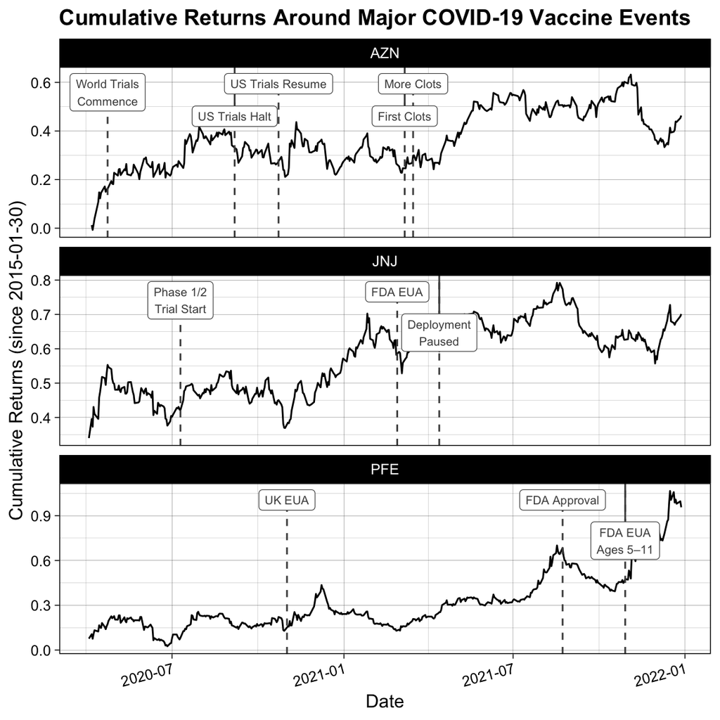

### Observations

- Possibly more activity during clinical trials and emergency use events
  - JNJ: Phase ½ trials
  - AZN: US trials halt and result
  - PFE: UK emergency use

# Conducting Event Studies

## Selecting Statistical Models for Expected Return

- **Market Model, Market Adjusted Model,** and **Comparison Period Mean Adjusted Model** are chosen primarily for firm-specific events.
  - Market Model: $R_{i,t} = \alpha_i + \beta_i \cdot R_{m,t} + \epsilon_{i,t}$
  - Market Adjusted Model: $R_{i,t} = R_{m,t} + \epsilon_{i,t}$
  - Comparison Period Mean Adjusted Model: $R_{i,t} = \mu_i + \epsilon_{i,t}$
- **Fama-French 3 Factor Model** for market-wide events.

  $$R_i - R_f = \alpha + \beta_1 \cdot (R_m - R_f) + \beta_2 \cdot \text{SMB} +\beta_3 \cdot \text{HML} + \epsilon$$
  - $R_i - R_f$: Actual return of stock
  - $\alpha$: (intercept) Expected excess return of stock
  - $R_m - R_f$: Market excess return
  - **SMB (small minus big)**: Size premium
  - **HML (high minus low)**: Value premium
  - $\beta_{1,2,3}$: Est. coefficients for market, size, and value factors
  - $\epsilon$: Abnormal returns

# Results

## Market-Wide Events

| Ticker | Event | Date | p_event | p_post |
| --- | --- | --- | --- | --- |
| AZN | PHEIC announcement | 2020-01-30 | 0.5064 | 0.1441 |
| JNJ | PHEIC announcement | 2020-01-30 | 0.9344 | 0.3763 |
| PFE | PHEIC announcement | 2020-01-30 | 0.0050 | 0.5665 |
| AZN | PFE first vaccine approval | 2020-12-31 | 0.5004 | 0.2477 |
| JNJ | PFE first vaccine approval | 2020-12-31 | 0.4234 | 0.9214 |
| PFE | PFE first vaccine approval | 2020-12-31 | 0.7154 | 0.5321 |
| AZN | PHEIC removal | 2023-05-05 | 0.3141 | 0.3658 |
| JNJ | PHEIC removal | 2023-05-05 | 0.5492 | 0.3854 |
| PFE | PHEIC removal | 2023-05-05 | 0.7366 | 0.6446 |

## Firm-Specific Events

|  | MAM_p | CMA_p | MM_p |
| --- | --- | --- | --- |
| AZN Global Trials Start (2020-04-23) | 0.9900 | 0.9258 | 0.0006 |
| AZN US Trials Halt (2020-09-06) | 0.2776 | 0.0608 | 0.5435 |
| AZN US Trials Resume (2020-10-23) | 0.2365 | 0.0915 | 0.8716 |
| AZN First Report of Blood Clots (2021-03-07) | 0.5448 | 0.7290 | 0.9193 |
| AZN More Blood Clot Reports (2021-03-16) | 0.7313 | 0.9640 | 0.3247 |
| JNJ Phase 1/2 Start (2020-07-10) | 0.8810 | 0.9453 | 0.2948 |
| JNJ USFDA Emergency Use (2021-02-27) | 0.5680 | 0.0142 | 0.9536 |
| JNJ Emerge Cases of Blood Clots (2021-04-13) | 0.9973 | 0.9657 | 0.3693 |
| PFE Phase 3 Results + UK EUA (2020-11) | 0.8083 | 0.0519 | 0.1490 |
| PFE First US FDA Approval (2021-08-23) | 0.1980 | 0.0980 | 0.0002 |
| PFE FDA EUA for Age 5-11 (2021-10-29) | 0.9702 | 0.9856 | 0.9546 |

## Conclusions

### Methodology

- Abnormality is model-dependent and *p*-values are interpreted differently under different models.

# Thank You! Questions?

## References

Perlin M (2023). *yfR: Downloads and Organizes Financial Data from Yahoo Finance*. R package version 1.1.0, https://github.com/ropensci/yfR.

Wickham H (2016). *ggplot2: Elegant Graphics for Data Analysis*. Springer-Verlag New York. ISBN 978-3-319-24277-4, https://ggplot2.tidyverse.org.

World Health Organization (2023). *Status of COVID-19 Vaccines within WHO EUL/PQ evaluation process*. Guidance Document, https://extranet.who.int/pqweb/key-resources/documents/status-covid-19-vaccines-within-who-eulpq-evaluation-process.

Nguyen M (2025). *A Guide on Data Analysis*. Bookdown, https://bookdown.org/mike/data_analysis/

Dal-Ré R (2023). *The winding 12-month journey of the AstraZeneca COVID-19 vaccine since its first administration to humans*. Therapie, 78(3), 293–302. https://doi.org/10.1016/j.therap.2022.07.003

Brice Y, Morgan L, Kirmani M, Kirmani M, & Udeh M C (2023). *COVID-19 Vaccine Evolution and Beyond.* Neuroscience insights, 18, 26331055231180543. https://doi.org/10.1177/26331055231180543

Müller S (2023). *Choosing the Right Approach: A Comprehensive Guide to Estimating Expected Returns.* https://eventstudy.de/models/expected_return.html#economic-models

Wolf M, Schimmer M, Levchenko A, & Müller S (2014). *EventStudyTools (Research Apps)*, St.Gallen, http://www.eventstudytools.com.

Fama E F, French K R (2025). *Current Research Returns*. Data Library, https://mba.tuck.dartmouth.edu/pages/faculty/ken.french/data_library.html

Martinez-Blasco M, Serrano V, Prior F & Cuadros J (2023). *Analysis of an event study using the Fama–French five-factor model: teaching approaches including spreadsheets and the R programming language*. Financ Innov 9, 76. https://doi.org/10.1186/s40854-023-00477-3